# Bellabeat – Estudo de Caso

Guilherme Venturini de Castro

2025-03-30

## 1. Perguntar

**Como a análise pode ajudar?**  
A análise identificará padrões comportamentais claros que possam ser usados para desenvolver campanhas eficazes para atrair e manter clientes engajadas com dispositivos da Bellabeat.

## 2. Preparar

**Fonte dos dados:**  
FitBit Fitness Tracker Data – Kaggle  
https://www.kaggle.com/datasets/arashnic/fitbit

**Licença e acesso:**  
Dados públicos (Open Data). Autor original: **Möbius** (Kaggle).

## 3. Processar

```r
# Caminho dos arquivos
data_path <- "mturkfitbit_export_3.12.16-4.11.16/Fitabase Data 3.12.16-4.11.16/"

# Carregar arquivos
activity <- read_csv(paste0(data_path, "dailyActivity_merged.csv")) %>%
  clean_names()
```

## 4. Explorar Dados

```r
# Resumo dos dados
skim_without_charts(activity)
```

Data summary

| Name | activity |
| --- | --- |
| Number of rows | 457 |
| Number of columns | 15 |
| _______________________ |  |
| Column type frequency: |  |
| character | 1 |
| numeric | 14 |
| ________________________ |  |
| Group variables | None |

**Variable type: character**

| skim_variable | n_missing | complete_rate | min | max | empty | n_unique | whitespace |
| --- | --- | --- | --- | --- | --- | --- | --- |
| activity_date | 0 | 1 | 8 | 9 | 0 | 32 | 0 |

**Variable type: numeric**

| skim_variable | n_missing | complete_rate | mean | sd | p0 | p25 | p50 | p75 | p100 |
| --- | --- | --- | --- | --- | --- | --- | --- | --- | --- |
| id | 0 | 1 | 4.628595e+09 | 2.293781e+09 | 1503960366 | 2.347168e+09 | 4.057193e+09 | 6.391747e+09 | 8.877689e+09 |
| total_steps | 0 | 1 | 6.546560e+03 | 5.398490e+03 | 0 | 1.988000e+03 | 5.986000e+03 | 1.019800e+04 | 2.849700e+04 |
| total_distance | 0 | 1 | 4.660000e+00 | 4.080000e+00 | 0 | 1.410000e+00 | 4.090000e+00 | 7.160000e+00 | 2.753000e+01 |
| tracker_distance | 0 | 1 | 4.610000e+00 | 4.070000e+00 | 0 | 1.280000e+00 | 4.090000e+00 | 7.110000e+00 | 2.753000e+01 |
| logged_activities_distance | 0 | 1 | 1.800000e-01 | 8.500000e-01 | 0 | 0.000000e+00 | 0.000000e+00 | 0.000000e+00 | 6.730000e+00 |
| very_active_distance | 0 | 1 | 1.180000e+00 | 2.490000e+00 | 0 | 0.000000e+00 | 0.000000e+00 | 1.310000e+00 | 2.192000e+01 |
| moderately_active_distance | 0 | 1 | 4.800000e-01 | 8.300000e-01 | 0 | 0.000000e+00 | 2.000000e-02 | 6.700000e-01 | 6.400000e+00 |
| light_active_distance | 0 | 1 | 2.890000e+00 | 2.240000e+00 | 0 | 8.700000e-01 | 2.930000e+00 | 4.460000e+00 | 1.251000e+01 |
| sedentary_active_distance | 0 | 1 | 0.000000e+00 | 1.000000e-02 | 0 | 0.000000e+00 | 0.000000e+00 | 0.000000e+00 | 1.000000e-01 |
| very_active_minutes | 0 | 1 | 1.662000e+01 | 2.892000e+01 | 0 | 0.000000e+00 | 0.000000e+00 | 2.500000e+01 | 2.020000e+02 |
| fairly_active_minutes | 0 | 1 | 1.307000e+01 | 3.621000e+01 | 0 | 0.000000e+00 | 1.000000e+00 | 1.600000e+01 | 6.600000e+02 |
| lightly_active_minutes | 0 | 1 | 1.700700e+02 | 1.222100e+02 | 0 | 6.400000e+01 | 1.810000e+02 | 2.570000e+02 | 7.200000e+02 |
| sedentary_minutes | 0 | 1 | 9.952800e+02 | 3.370200e+02 | 32 | 7.280000e+02 | 1.057000e+03 | 1.285000e+03 | 1.440000e+03 |
| calories | 0 | 1 | 2.189450e+03 | 8.154800e+02 | 0 | 1.776000e+03 | 2.062000e+03 | 2.667000e+03 | 4.562000e+03 |

```r
head(activity)
```

```
## # A tibble: 6 × 15
##           id activity_date total_steps total_distance tracker_distance
##        <dbl> <chr>               <dbl>          <dbl>            <dbl>
## 1 1503960366 3/25/2016           11004           7.11             7.11
## 2 1503960366 3/26/2016           17609          11.6             11.6
## 3 1503960366 3/27/2016           12736           8.53             8.53
## 4 1503960366 3/28/2016           13231           8.93             8.93
## 5 1503960366 3/29/2016           12041           7.85             7.85
## 6 1503960366 3/30/2016           10970           7.16             7.16
## # ℹ 10 more variables: logged_activities_distance <dbl>,
## #   very_active_distance <dbl>, moderately_active_distance <dbl>,
## #   light_active_distance <dbl>, sedentary_active_distance <dbl>,
## #   very_active_minutes <dbl>, fairly_active_minutes <dbl>,
## #   lightly_active_minutes <dbl>, sedentary_minutes <dbl>, calories <dbl>
```

## 5. Analisar

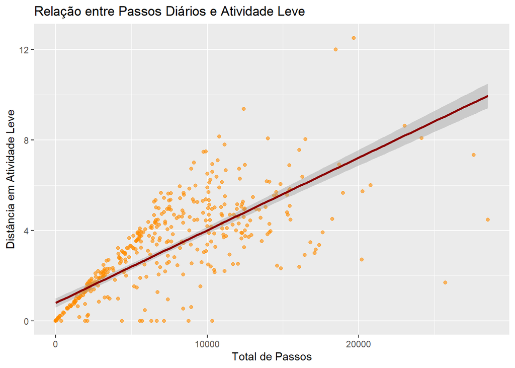

```r
# Correlação entre passos e Light Active Distance
ggplot(activity, aes(x = total_steps, y = light_active_distance)) +
  geom_point(alpha = 0.6, color = "darkorange") +
  geom_smooth(method = "lm", color = "darkred") +
  labs(title = "Relação entre Passos Diários e Atividade Leve",
       x = "Total de Passos",
       y = "Distância em Atividade Leve")
```

```r
# Cálculo da correlação
cor(activity$total_steps, activity$light_active_distance, use = "complete.obs")
```

```
## [1] 0.7755616
```

## 6. Compartilhar

### Principais Insights

**Correlação entre Passos Diários e Distância em Atividades Leves:** - Correlação forte (0.776), indicando que a maioria das atividades registradas são leves, como pequenas caminhadas ou tarefas diárias simples. - Essa informação sugere uma oportunidade estratégica para incentivar atividades leves ao longo do dia.

## 7. Agir

### Sugestões para Bellabeat

- **Campanha “Pequenos Passos, Grandes Resultados”**:  
  Incentivar pequenas caminhadas diárias, pausas ativas, e atividades rotineiras que somam um número significativo de passos, promovendo a conscientização sobre como pequenas ações podem ter grandes impactos.
- **Gamificação no App**:  
  Implementar desafios semanais ou diários baseados em passos leves, com recompensas para aumentar a motivação e engajamento dos usuários.

### Próximos Passos

- Expandir a pesquisa com uma base de dados maior.
- Implementar feedback de usuário direto no app para validar campanhas.
- Monitorar continuamente os resultados através de um dashboard para tomada de decisões ágil.

**Conclusão**  
Este estudo identificou uma clara oportunidade para Bellabeat desenvolver ações eficazes centradas em atividades leves, aumentando o engajamento e valor do produto para as usuárias.

**Fim do Estudo de Caso**